# Explaining Predictions with Shapley Values in R

Brandon M. Greenwell https://github.com/bgreenwell (University of Cincinnati)  
2023-05-02

# 1 Introduction

The *Shapley value* (Shapley 2016) is an idea from coalitional/cooperative game theory. In a coalitional game (i.e., a competetive game between groups of players called *coalitions*), assume we have $p$ players that form a grand coalition ($S$) worth a certain payout ($\Delta_S$). Suppose we also know how much any smaller coalition ($Q \subseteq S$) (i.e., any subset of $p$ players) is worth ($\Delta_Q$). The goal is to distribute the total payout $\Delta_S$ to the individual $p$ players in a “fair” way; that is, so that each player receives their “fair” share. The Shapley value is one such solution and the only one that uniquely satisfies a particular set of “fairness properties.”

Let $v$ be a *characteristic function* (or mapping) that assigns a value to each subset of players; in particular, $v : 2^p \rightarrow \mathbb{R}$, where $v\left(S\right) = \Delta_S$, $v\left(\emptyset\right) = 0$, and $\emptyset$ is the empty set (i.e., zero players). Let $\phi_i\left(v\right)$ be the contribution (or portion of the total payout) attributed to player $i$ in a particular game with total payout $v\left(S\right) = \Delta_S$. The Shapley values $\left\{\phi_i\right\}_{i=1}^p$ satisfy the following four properties:

1. Efficiency: $\sum_{i = 1} ^ p \phi_i\left(v\right) = \Delta_S$.
2. Null player: $\forall W \subseteq S \setminus \left\{i\right\}: \Delta_W = \Delta_{W \cup \left\{i\right\}} \implies \phi_i\left(v\right) = 0$.
3. Symmetry: $\forall W \subseteq S \setminus \left\{i, j\right\}: \Delta_{W \cup \left\{i\right\}} = \Delta_{W \cup \left\{j\right\}} \implies \phi_i\left(v\right) = \phi_j\left(v\right)$.
4. Linearity: If $v$ and $w$ are functions describing two coalitional games, then $\phi_i\left(v + w\right) = \phi_i\left(v\right) + \phi_i\left(w\right)$.

The above properties can be interpreted as follows: 1) the individual player contributions sum to the total payout, hence, are implicitly normalized; 2) if a player does not contribute to any coalition they receive a payout of zero; 3) if two players have the same impact across all coalitions, they receive equal payout; and 4) the local contributions are additive across different games.

Shapley (2016) showed that the unique solution satisfying the above properties is given by

$$\begin{equation}
\phi_i\left(x\right) = \frac{1}{p!} \sum_{\mathcal{O} \in \pi\left(p\right)} \left[v\left(S^\mathcal{O} \cup i\right) - v\left(S^\mathcal{O}\right)\right], \quad i = 1, 2, \dots, p,
\tag{1}
\end{equation}$$
where $\mathcal{O}$ is a specific permutation of the players indices $\left\{1, 2, \dots, p\right\}$, $\pi\left(p\right)$ is the set of all such permutations of size $p$, and $S^\mathcal{O}$ is the set of players joining the coalition before player $i$.

In other words, the Shapley value is the average marginal contribution of a player across all possible coalitions in a game. Another way to interpret Equation (1) is as follows. Imagine the coalitions (i.e., subsets of players) being formed one player at a time (which can happen in different orders), with the $i$-th player demanding a fair contribution/payout of $v\left(S^\mathcal{O} \cup i\right) - v\left(S^\mathcal{O}\right)$. The Shapley value for player $i$ is given by the average of this contribution over all possible permutations in which the coalition can be formed.

A simple example may help clarify the main ideas. Suppose three friends (players)—Alex, Brad, and Brandon—decide to go out for drinks after work (the game). They shared a few pitchers of beer, but nobody payed attention to how much each person drank (collaborated). What’s a fair way to split the tab (total payout)? Suppose we knew the follow information, perhaps based on historical data:

- If Alex drank alone, he’d only pay $10.
- If Brad drank alone, he’d only pay $20.
- If Brandon drank alone, he’d only pay $10.
- If Alex and Brad drank together, they’d only pay $25.
- If Alex and Brandon drank together, they’d only pay $15.
- If Brad and Brandon drank together, they’d only pay $13.
- If Alex, Brad, and Brandon drank together, they’d only pay $30.

Note that $S = \left\{\text{Alex}, \text{Brad}, \text{Brandon}\right\}$ and that $\Delta_S = \$30$. With only three players, we can enumerate all possible coalitions. In Table 1, we list out all possible permutations of the three players along with the marginal contribution of each. Take the first row, for example. In this particular permutation, we start with Alex. We know that if Alex drinks alone, he’d spend $10, so his marginal contribution by entering first is $10. Next, we assume Brad enters the coalition. We know that if Alex and Brad drank together, they’d pay a total of $25, leaving $15 left over for Brad’s marginal contribution. Similarly, if Brandon joins the party last, his marginal contribution would be only $5 (the difference between $30 and $25). The Shapley value for each player is the average marginal contribution across all six possible permutations (these are the column averages reported in the last row).

Table 1: Marginal contribution for each permutation of the players {Alex, Brad, Brandon} (i.e., the order in which they arrive). The Shapley contribution is the average marginal contribution cross all permutations. (Notice how each row sums to the total bill of $30.)

[output not shown]

In this example, Brandon would get away with the smallest payout (i.e., have to pay the smallest portion of the total tab). The next time the bartender asks how you want to split the tab, whip out a pencil and do the math! In the next section, we’ll show how the same idea can be used to help quantify the contribution each feature value makes to its corresponding prediction in a machine learning model.

# 2 Shapley values for explaining predictions

Štrumbelj and Kononenko (2014) suggested using the Shapley value (1) to help explain predictions from a machine learning model. In the context of machine learning:

- a game is represented by the prediction task for a single observation $\boldsymbol{x} = \left(x_1, x_2, \dots, x_p\right)$ (i.e., there are $p$ features in total);
- the total payout/worth ($\Delta_S$) for $\boldsymbol{x}$ is the prediction for $\boldsymbol{x}$, denoted $\hat{f}\left(\boldsymbol{x}\right)$, minus the average prediction for all training observations (call this the baseline prediction, which we’ll denote by $\bar{f}$);
- the players are the individual feature values of $\boldsymbol{x}$ that collaborate to receive the payout (i.e., $\hat{f}\left(\boldsymbol{x}\right) - \bar{f}$).

From the last point, it’s important to note that Shapley explanations are not trying to quantify the contribution each feature value in $\boldsymbol{x}$ makes to its prediction $\hat{f}\left(\boldsymbol{x}\right)$, but rather to the quantity $\hat{f}\left(\boldsymbol{x}\right) - \bar{f}$, the difference between its prediction and the baseline. This seems to be a common source of confusion in interpreting a set of Shapley explanations from a given model.

In the following sections, we’ll discuss several popular ways to compute Shapley values in practice.

## Choice of characteristic function $v$

The challenge of using Shapley values for the purpose of explaining predictions is in defining the functional form of $v$. As discussed in Chen et al. (2020a), there are several ways to do this. However, since we are primarily interested in understanding how much each feature contributed to a particular prediction, $v$ is typically related to a conditional expectation of the model’s prediction. Chen et al. (2020a) make the distinction between two possibilities, each of which differs in their conditioning argument. The Shapley value implementations discussed in this paper (e.g., MC SHAP and Tree SHAP) rely on what Chen et al. (2020a) call the *interventional conditional expectation*, which can be expressed using Pearl’s $do\left(\cdot\right)$ operator (Pearl 2009):

$$\begin{equation}
\begin{split}
v\left(S\right) &= \mathbb{E}\left[f\left(\boldsymbol{x}_S, \boldsymbol{x}_{S^c}\right) | do\left(\boldsymbol{x}_S\right)\right] \\
&= \int f\left(\boldsymbol{x}_S, \boldsymbol{x}_{S^c}\right) p\left(\boldsymbol{x}_{S^c}\right) d \boldsymbol{x}_{S^c},
\end{split}
\tag{2}
\end{equation}$$

The following sections detail several algorithms for estimating Shapley explanations in practice.

## Monte Carlo (MC) SHAP: approximate Shapley values via Monte Carlo simulation

Computing the exact Shapley value is computationally infeasible, even for moderately large $p$. To that end, Štrumbelj and Kononenko (2014) suggest a Monte Carlo approximation, which we’ll call SampleSHAP[^1], that assumes independent features[^2]. Their approach is described in Algorithm 1 below.

**Algorithm 1:** Approximating the $i$-th feature’s contribution to $f\left(\boldsymbol{x}\right)$.

1. For $j = 1, 2, \dots, R$:
   1. Select a random permutation $\mathcal{O}$ of the feature values $x_1, x_2, \dots, x_p$.
   2. Select a random instance $\boldsymbol{w}$ from the set of training observations $\boldsymbol{X}$.
   3. Construct two new instances as follows:
      - $\boldsymbol{b}_1 = \boldsymbol{x}$, but all the features in $\mathcal{O}$ that appear after feature $x_i$ get their values swapped with the corresponding values in $\boldsymbol{w}$.
      - $\boldsymbol{b}_2 = \boldsymbol{x}$, but feature $x_j$, as well as all the features in $\mathcal{O}$ that appear after $x_j$, get their values swapped with the corresponding values in $\boldsymbol{w}$.
   4. Compute the difference in predictions: $\phi_{ij}\left(\boldsymbol{x}\right) = f\left(\boldsymbol{b}_1\right) - f\left(\boldsymbol{b}_2\right)$.
2. Aggregate the results: $\phi_i\left(\boldsymbol{x}\right) = \sum_{j = 1} ^ R \phi_{ij}\left(\boldsymbol{x}\right) / R$.

Here, A single estimate of the contribution of $x_i$ to $f\left(\boldsymbol{x}\right) - \bar{f}$ is nothing the more than the difference between two predictions, where each prediction is based on a set of “Frankenstein instances”[^3] that are constructed by swapping out values between the instance being explained ($\boldsymbol{x}$) and an instance selected at random from the training data. To help stabilize the results, the procedure is repeated a large number, say, $R$, times, and the results averaged together. Note that Algorithm 1 can be parallelized across features or MC repetitions.

If there are $p$ features and $m$ instanced to be explained, this requires $2 \times R \times p \times m$ predictions (or calls to a scoring function). In practice, this can be quite computationally demanding, especially since $R$ needs to be large enough to produce good approximations to each $\phi_i\left(x\right)$. How large does $R$ need to be to produce accurate explanations? It depends on the variance of each feature in the observed training data, but typically $R \in \left[30, 100\right]$ will suffice. In a later section, we’ll discuss a particularly optimized implementation of Algorithm 1 that only requires $2mp$ calls to a scoring function.

Even with certain optimizations or parallel processing, MC SHAP can be computationally prohibitive if you need to explain a large number of predictions Fortunately, you often only need to explain a handful of predictions, for example the most extreme predictions. However, generating individual explanations for the entire training set, or a large enough sample thereof, can be useful for generating aggregated (i.e., *global*) model summaries, like Shapley-based variable importance plots (Lundberg et al. 2020).

A simple R implementation of Algorithm 1 is given below. Here, `obj` is a fitted model with scoring function `f()` (e.g., `predict()`), `R` is the number of MC repetitions to perform, `feature` gives the name of the corresponding feature in `x` to be explained, and `X` is the training set of features.

```r
sample.shap <- function(f, obj, R, x, feature, X) {
  phi <- numeric(R)  # to store Shapley values
  N <- nrow(X)   # sample size
  p <- ncol(X)   # number of features
  b1 <- b2 <- x  # initialize new instances
  for (m in seq_len(R)) {
    w <- X[sample(N, size = 1), ]  # sample random obs from X     # (step 2. b.)
    ord <- sample(names(w))  # random permutation of features     #
    swap <- ord[seq_len(which(ord == feature) - 1)]               #
    b1[swap] <- w[swap]                                           # (step 1. c.)
    b2[c(swap, feature)] <- w[c(swap, feature)]                   # (step 1. c.)
    phi[m] <- f(obj, newdata = b1) - f(obj, newdata = b2)         # (step d.)
  }                                                               #
  mean(phi)  # return approximate feature contribution            # (step 2.)
}
```

## Linear SHAP: shapley values from additive linear models

First, lets discuss how a feature’s value contributes to a prediction $f\left(\boldsymbol{x}\right)$ in an additive linear model with independent features. That is, let’s assume for a moment that $f$ takes the form
$$\begin{equation}
\nonumber
f\left(\boldsymbol{x}\right) = \beta_0 + \beta_1 x_1 + \dots + \beta_p x_p
\end{equation}$$

Recall that the contribution of $x$_i (the $i$-th feature component of $\boldsymbol{x}$) to the prediction $f\left(\boldsymbol{x}\right)$ is the difference between $f\left(\boldsymbol{x}\right)$ and the expected prediction if the $i$-th feature’s value were not known:
$$\begin{equation}
\nonumber
\begin{split}
\phi_i\left(\boldsymbol{x}\right) &= \beta_0 + \dots + \beta_i x_i + \dots + \beta_p x_p \\ &\quad\quad - \left(\beta_0 + \dots + \beta_i \bar{x}_i + \dots + \beta_p \bar{x}_p\right) \\
&= \beta_i \left(x_i - \bar{x}_i\right)
\end{split},
\end{equation}$$
where, for example, $\bar{x}_i$ corresponds to the sample mean of the $i$-th features values in the training sample. For a proof, see Aas et al. (2020). The quantity $\phi_i\left(\boldsymbol{x}\right)$ is also referred to as the *situational importance* of $x_i$ (Achen 1982).

Note that if you’re using R, then $\beta_i \left(x_i - \bar{x}_i\right)$ is exactly what’s returned by R’s `predict()` method when applied to `lm/glm` models, provided you specify `type = "terms"`; see `?predict.lm` for details.

## Kernel SHAP: approximate Shapley values using kernel approximations

Kernel SHAP uses a linear regression-based approximation to estimate Shapley values from a given model. It is model-agnostic in the sense that it can be applied in the same way to any type of supervised learning model.

In the Kernel SHAP formulation, the computation is represented as a linear model, with a specific Shapley Kernel.

Kernel SHAP samples coalitions $z_k' \in \{0,1\}^M$, with $k \in \{1, \ldots, K\}$, where ‘0’ signifies that a feature is absent and ‘1’ that it is present. A function $h_x: Z \mapsto X$ maps coalitions to the feature space, making it possible to get the predictions for the sampled coalitions: $f(h_x(z_k'))$. A dataset is generated by sampling coalitions and computing their model predictions. A weighted linear model is then fitted with the coalition vector as features and the model predictions as target. The weight used is the kernel:

$$\pi_{x}(z')=\frac{(M-1)}{\binom{M}{|z'|}|z'|(M-|z'|)}$$

where $M$ is the maximum coalition size (for tabular data the number of features) and $|z'|$ is the number of 1’s in the coalition vector, or the number of features that are present. The function $h_x$ maps elements of the coalition vector with a 1 to the original feature vector, and the elements with 0’s to the respective feature values of a randomly sampled data point. The estimated coefficients in this weighted linear model can be interpreted as Shapley value estimates. The accuracy of the estimate depends on the size of the coalitions that are sampled. Like SampleSHAP and LinearSHAP, Kernel SHAP assumes independent features. The Kernel SHAP supposedly requires less computational power than SampleSHAP to obtain a similar approximation accuracy (i.e., fewer replications).

**NOTES:**

(Christoph, this was my initial “thought dump”, feel free to delete or use.)

Unlike sampling-based approaches (e.g., MC SHAP), Kernel SHAP does not provide estimates of uncertainlty. An improvemed version of Kernel SHAP was proposed in Covert and Lee (2021). This version is unbiased and has better convergence.

## Tree SHAP: efficient Shapley values for tree ensembles

**NOTES:**

Tree SHAP assumes “less” feature independence in the sense that it accounts for some of the dependence, but not all (Aas et al. 2020).

Only applicable to tree-based models, and implemented for only a few algorithms (e.g., XGBoost and LightGBM).

# 3 Implementations in R

Probably the first, and most widely used implementation of Shapley explanations is the Python shap library (Lundberg and Lee 2017a), which provides a Python implementation of SampleSHAP, KernelSHAP, TreeSHAP, and a few other model-specific Shapley methods (e.g., DeepSHAP, which is provides approximate Shapley values for deep learning models).

There are several R packages available for computing Shapley-based feature contributions. You can perform a quick search for CRAN packages related to Shapley value using the pkgsearch (Csárdi and Salmon 2020):

```r
pkgsearch::ps("Shapley")  # set `format = "long"` for more detailed results
```

```
- "Shapley" -------------------------- 16 packages in 0.008 seconds -
  #     package              version by                          @
  1 100 fastshap             0.0.7   Brandon Greenwell         10M
  2  51 shapr                0.2.0   Martin Jullum              2y
  3  51 ShapleyValue         0.2.0   Jingyi Liang               1y
  4  22 vip                  0.3.2   Brandon Greenwell          2y
  5  13 kappalab             0.4.7   Ivan Kojadinovic           7y
  6  13 iml                  0.11.1  Christoph Molnar          29d
  7  11 GameTheoryAllocation 1.0     Alejandro Saavedra-Nieves  6y
  8  10 shapper              0.1.3   Szymon Maksymiuk           2y
  9  10 SHAPforxgboost       0.1.1   Yang Liu                   2y
 10   9 matchingR            1.3.3   Jan Tilly                  1y
```

While we won’t demonstarte use of the package, it’s worth point readers to the shapr package . As previously discussed, one drawback of traditional Shapley values (like the ones computed by the MC SHAP procedure) is the assumption of independent features (an assumption made by many IML procedures, in fact). To that end, the shapr package implements Shapley explanations that can account for the dependence between features , resulting in significantly more accurate approximations to the Shapley values. The package also includes an implementation of KernelSHAP that’s consistent with the shap package for Python.

Tree SHAP has been directly incorporated into most implementations of XGBoost (including xgboost ), CatBoost , and LightGBM . Both fastshap and SHAPforxgboost provide an interface to xgboost’s TreeSHAP implementation.

The remainder of this article will focus applying Shapley values to machine learning using a handful of packages: fastshap (Greenwell 2020), iml (Molnar and Schratz 2020), iBreakDown (Biecek et al. 2020), and lightgbm (Shi et al. 2022). The first three packages all prvide an implementation of MC SHAP (i.e., Algorithm 1), while the latter includes an implementation of Tree SHAP; note that xgboost (Chen et al. 2020b), an efficient boosting library similar to `lightgbm`, provides similar Tree SHAP functionality.

fastshap provides an efficient implementation of SampleSHAP and makes it a viable option for explaining the predictions from model’s where efficient model-specific Shapley methods do not exist or are not yet implemented.

The iml package provides the `Shapley()` function, which is a direct implementation of Algorithm 1. It is written in R6 (Chang 2021). Moreover, the iml package provides a standard interface to several other interpretable machine learning (IML) algorithms, whence the package name.

Package iBreakDown implements a general approach to explaining the predictions from supervised models, called *Break Down* (Gosiewska and Biecek 2019). MC SHAP values can be computed as a special case from random Break Down profiles; see `?iBreakDown::shap` for details.

While several of these packages provide their own plotting function for visualizing the output, the shapviz package (Mayer 2022) provides a generic set of function for plotting Shapley explanations with direct support for a number of packages (including fastshap, lightgbm, xgboost, and shapr, to name a few). The package is general enough and can be applied to any set of Shapley explanations stored in an ordinary R matrix.

# 4 Example: explaining survival on the Titanic

In this section, we’ll look at a simple example related to predicting survival on the ill-fated Titanic. We’ll use this as an opportunity to introduce all four packages mentioned above. To start, we’ll load…

```r
library(fastshap)

# Use one of fastshap's imputed versions of the Titanic data
head(titanic <- titanic_mice[[1L]])
```

```
  survived pclass   age    sex sibsp parch
1      yes      1 29.00 female     0     0
2      yes      1  0.92   male     1     2
3       no      1  2.00 female     1     2
4       no      1 30.00   male     1     2
5       no      1 25.00 female     1     2
6      yes      1 48.00   male     0     0
```

While lightgbm now supports categorical features, it’s easier just to re-encode binary variables as 0/1, which we do below. We then construct a matrix (`X`) containing only the feature columns before calling `lightgbm()` too fit a model using log loss (the number of trees, or `nrounds`, was found using 5-fold cross-validation vi the `lgb.cv()` function):

```r
library(lightgbm)

# Re-encode binary variables as 0/1
titanic$survived <- ifelse(titanic$survived == "yes", 1, 0)
titanic$sex <- ifelse(titanic$sex == "male", 1, 0)

# Matrix of only predictor values
X <- data.matrix(subset(titanic, select = -survived))

params <- list(
  num_leaves = 10L,
  learning_rate = 0.1,
  objective = "binary"
)

set.seed(1420)  # for reproducibility
bst <- lightgbm(X, label = titanic$survived, params = params, nrounds = 45,
                verbose = 0)
```

```
[LightGBM] [Warning] Auto-choosing col-wise multi-threading, the overhead of testing was 0.000909 seconds.
You can set `force_col_wise=true` to remove the overhead.
```

To illustrate the simplest use of Shapley values for quantifying feature contributions, we need an observation to predict. While we can use any observation from the training set, we’ll construct an observation for a new passenger. Everyone, meet Jack:

```r
jack.dawson <- data.matrix(data.frame(
  #survived = 0L,  # in case you haven't seen the movie
  pclass = 3L,     # third-class passenger
  age = 20.0,      # twenty years old
  sex = 1L,        # male
  sibsp = 0L,      # no siblings/spouses aboard
  parch = 0L       # no parents/children aboard
))  # lightgbm doesn't like data frames
```

Note that fastshap, iml, and iBreakDown typically require a predefined prediction wrapper; that is, a simple function that tells each package how to extract the appropriate predictions from the fitted model. In this case, for comparison with Tree SHAP, our prediction wrapper will return the predictions on the raw (i.e., logit) scale:

```r
pfun <- function(object, newdata) {  # prediction wrapper
  predict(object, data = data.matrix(newdata), rawscore = TRUE)
}

# Compute Jack's predicted likelihood of survival
(jack.logit <- pfun(bst, newdata = jack.dawson))  # logit scale
```

```
[1] -1.732893
```

```r
(jack.prob <- plogis(jack.logit))  # probability scale
```

```
[1] 0.1502179
```

```r
ex.lightgbm <- predict(bst, data = jack.dawson, predcontrib = TRUE)
colnames(ex.lightgbm) <- c(colnames(X), "baseline")
ex.lightgbm
```

```
         pclass        age        sex      sibsp       parch
[1,] -0.4635056 0.06744438 -0.8439261 0.08515607 -0.01917919
       baseline
[1,] -0.5588822
```

```r
sum(ex.lightgbm)  # since baseline is included, this should some to prediction
```

```
[1] -1.732893
```

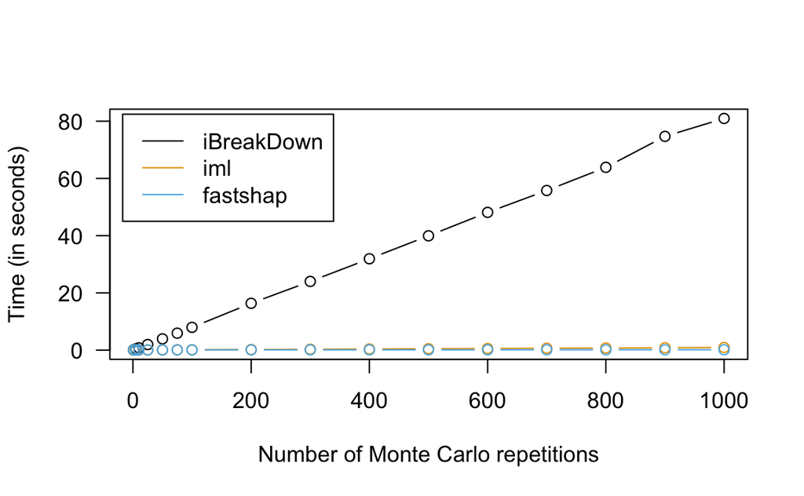

In this example, for $R = 1000$ MC repetitions, fastshap is roughly `7.3902439` times faster than iml, and nearly `658.1300813` times faster than iBreakDown.